# Risk Factor Analysis

## Outcome Variable

**Outcome Variable:** pers_wast

## Predictor Variables

**Intervention Variable:** fhtcm

**Adjustment Set:**

- arm
- W_mage
- W_fage
- meducyrs
- feducyrs
- W_mhtcm
- W_mwtkg
- W_mbmi
- single
- delta_W_mage
- delta_W_fage
- delta_meducyrs
- delta_feducyrs
- delta_W_mhtcm
- delta_W_mwtkg
- delta_W_mbmi
- delta_single

## Stratifying Variables

The analysis was stratified on these variable(s):

- agecat
- studyid
- country

## Data Summary

| agecat | studyid | country | fhtcm | pers_wast | n_cell | n |
| --- | --- | --- | --- | --- | --- | --- |
| 0-24 months | COHORTS | GUATEMALA | >=167 cm | 0 | 55 | 424 |
| 0-24 months | COHORTS | GUATEMALA | >=167 cm | 1 | 1 | 424 |
| 0-24 months | COHORTS | GUATEMALA | <162 cm | 0 | 237 | 424 |
| 0-24 months | COHORTS | GUATEMALA | <162 cm | 1 | 12 | 424 |
| 0-24 months | COHORTS | GUATEMALA | [162-167) cm | 0 | 116 | 424 |
| 0-24 months | COHORTS | GUATEMALA | [162-167) cm | 1 | 3 | 424 |
| 0-24 months | Keneba | GAMBIA | >=167 cm | 0 | 1038 | 1720 |
| 0-24 months | Keneba | GAMBIA | >=167 cm | 1 | 69 | 1720 |
| 0-24 months | Keneba | GAMBIA | <162 cm | 0 | 112 | 1720 |
| 0-24 months | Keneba | GAMBIA | <162 cm | 1 | 12 | 1720 |
| 0-24 months | Keneba | GAMBIA | [162-167) cm | 0 | 466 | 1720 |
| 0-24 months | Keneba | GAMBIA | [162-167) cm | 1 | 23 | 1720 |
| 0-24 months | PROBIT | BELARUS | >=167 cm | 0 | 11650 | 12524 |
| 0-24 months | PROBIT | BELARUS | >=167 cm | 1 | 82 | 12524 |
| 0-24 months | PROBIT | BELARUS | <162 cm | 0 | 165 | 12524 |
| 0-24 months | PROBIT | BELARUS | <162 cm | 1 | 3 | 12524 |
| 0-24 months | PROBIT | BELARUS | [162-167) cm | 0 | 619 | 12524 |
| 0-24 months | PROBIT | BELARUS | [162-167) cm | 1 | 5 | 12524 |
| 0-24 months | SAS-CompFeed | INDIA | >=167 cm | 0 | 358 | 824 |
| 0-24 months | SAS-CompFeed | INDIA | >=167 cm | 1 | 27 | 824 |
| 0-24 months | SAS-CompFeed | INDIA | <162 cm | 0 | 179 | 824 |
| 0-24 months | SAS-CompFeed | INDIA | <162 cm | 1 | 15 | 824 |
| 0-24 months | SAS-CompFeed | INDIA | [162-167) cm | 0 | 222 | 824 |
| 0-24 months | SAS-CompFeed | INDIA | [162-167) cm | 1 | 23 | 824 |
| 0-24 months | SAS-FoodSuppl | INDIA | >=167 cm | 0 | 89 | 370 |
| 0-24 months | SAS-FoodSuppl | INDIA | >=167 cm | 1 | 11 | 370 |
| 0-24 months | SAS-FoodSuppl | INDIA | <162 cm | 0 | 118 | 370 |
| 0-24 months | SAS-FoodSuppl | INDIA | <162 cm | 1 | 34 | 370 |
| 0-24 months | SAS-FoodSuppl | INDIA | [162-167) cm | 0 | 100 | 370 |
| 0-24 months | SAS-FoodSuppl | INDIA | [162-167) cm | 1 | 18 | 370 |
| 0-6 months | Keneba | GAMBIA | >=167 cm | 0 | 927 | 1489 |
| 0-6 months | Keneba | GAMBIA | >=167 cm | 1 | 32 | 1489 |
| 0-6 months | Keneba | GAMBIA | <162 cm | 0 | 103 | 1489 |
| 0-6 months | Keneba | GAMBIA | <162 cm | 1 | 7 | 1489 |
| 0-6 months | Keneba | GAMBIA | [162-167) cm | 0 | 411 | 1489 |
| 0-6 months | Keneba | GAMBIA | [162-167) cm | 1 | 9 | 1489 |
| 0-6 months | PROBIT | BELARUS | >=167 cm | 0 | 10330 | 12006 |
| 0-6 months | PROBIT | BELARUS | >=167 cm | 1 | 918 | 12006 |
| 0-6 months | PROBIT | BELARUS | <162 cm | 0 | 142 | 12006 |
| 0-6 months | PROBIT | BELARUS | <162 cm | 1 | 19 | 12006 |
| 0-6 months | PROBIT | BELARUS | [162-167) cm | 0 | 552 | 12006 |
| 0-6 months | PROBIT | BELARUS | [162-167) cm | 1 | 45 | 12006 |
| 6-24 months | COHORTS | GUATEMALA | >=167 cm | 0 | 55 | 424 |
| 6-24 months | COHORTS | GUATEMALA | >=167 cm | 1 | 1 | 424 |
| 6-24 months | COHORTS | GUATEMALA | <162 cm | 0 | 237 | 424 |
| 6-24 months | COHORTS | GUATEMALA | <162 cm | 1 | 12 | 424 |
| 6-24 months | COHORTS | GUATEMALA | [162-167) cm | 0 | 116 | 424 |
| 6-24 months | COHORTS | GUATEMALA | [162-167) cm | 1 | 3 | 424 |
| 6-24 months | Keneba | GAMBIA | >=167 cm | 0 | 1038 | 1720 |
| 6-24 months | Keneba | GAMBIA | >=167 cm | 1 | 69 | 1720 |
| 6-24 months | Keneba | GAMBIA | <162 cm | 0 | 112 | 1720 |
| 6-24 months | Keneba | GAMBIA | <162 cm | 1 | 12 | 1720 |
| 6-24 months | Keneba | GAMBIA | [162-167) cm | 0 | 466 | 1720 |
| 6-24 months | Keneba | GAMBIA | [162-167) cm | 1 | 23 | 1720 |
| 6-24 months | PROBIT | BELARUS | >=167 cm | 0 | 11650 | 12524 |
| 6-24 months | PROBIT | BELARUS | >=167 cm | 1 | 82 | 12524 |
| 6-24 months | PROBIT | BELARUS | <162 cm | 0 | 165 | 12524 |
| 6-24 months | PROBIT | BELARUS | <162 cm | 1 | 3 | 12524 |
| 6-24 months | PROBIT | BELARUS | [162-167) cm | 0 | 619 | 12524 |
| 6-24 months | PROBIT | BELARUS | [162-167) cm | 1 | 5 | 12524 |
| 6-24 months | SAS-CompFeed | INDIA | >=167 cm | 0 | 358 | 824 |
| 6-24 months | SAS-CompFeed | INDIA | >=167 cm | 1 | 27 | 824 |
| 6-24 months | SAS-CompFeed | INDIA | <162 cm | 0 | 179 | 824 |
| 6-24 months | SAS-CompFeed | INDIA | <162 cm | 1 | 15 | 824 |
| 6-24 months | SAS-CompFeed | INDIA | [162-167) cm | 0 | 222 | 824 |
| 6-24 months | SAS-CompFeed | INDIA | [162-167) cm | 1 | 23 | 824 |
| 6-24 months | SAS-FoodSuppl | INDIA | >=167 cm | 0 | 89 | 370 |
| 6-24 months | SAS-FoodSuppl | INDIA | >=167 cm | 1 | 11 | 370 |
| 6-24 months | SAS-FoodSuppl | INDIA | <162 cm | 0 | 118 | 370 |
| 6-24 months | SAS-FoodSuppl | INDIA | <162 cm | 1 | 34 | 370 |
| 6-24 months | SAS-FoodSuppl | INDIA | [162-167) cm | 0 | 100 | 370 |
| 6-24 months | SAS-FoodSuppl | INDIA | [162-167) cm | 1 | 18 | 370 |

The following strata were considered:

- agecat: 0-24 months, studyid: COHORTS, country: GUATEMALA
- agecat: 0-24 months, studyid: Keneba, country: GAMBIA
- agecat: 0-24 months, studyid: PROBIT, country: BELARUS
- agecat: 0-24 months, studyid: SAS-CompFeed, country: INDIA
- agecat: 0-24 months, studyid: SAS-FoodSuppl, country: INDIA
- agecat: 0-6 months, studyid: Keneba, country: GAMBIA
- agecat: 0-6 months, studyid: PROBIT, country: BELARUS
- agecat: 6-24 months, studyid: COHORTS, country: GUATEMALA
- agecat: 6-24 months, studyid: Keneba, country: GAMBIA
- agecat: 6-24 months, studyid: PROBIT, country: BELARUS
- agecat: 6-24 months, studyid: SAS-CompFeed, country: INDIA
- agecat: 6-24 months, studyid: SAS-FoodSuppl, country: INDIA

### Dropped Strata

Some strata were dropped due to rare outcomes:

- agecat: 0-24 months, studyid: COHORTS, country: GUATEMALA
- agecat: 0-24 months, studyid: PROBIT, country: BELARUS
- agecat: 6-24 months, studyid: COHORTS, country: GUATEMALA
- agecat: 6-24 months, studyid: PROBIT, country: BELARUS

## Methods Detail

We’re interested in the causal parameters $E[Y_a]$ for all values of $a \in \mathcal{A}$. These parameters represent the mean outcome if, possibly contrary to fact, we intervened to set all units to have $A=a$. Under the randomization and positivity assumptions, these are identified by the statistical parameters $\psi_a=E_W[E_{Y|A,W}(Y|A=a,W)]$. In addition, we’re interested in the mean of $Y$, $E[Y]$ under no intervention (the observed mean). We will estimate these parameters by using SuperLearner to fit the relevant likelihood factors – $E_{Y|A,W}(Y|A=a,W)$ and $p(A=a|W)$, and then updating our likelihood fit using a joint TMLE.

For unadjusted analyses ($W=\{\}$), initial likelihoods were estimated using Lrnr_glm to estimate the simple $E(Y|A)$ and Lrnr_mean to estimate $p(A)$. For adjusted analyses, a small library containing Lrnr_glmnet, Lrnr_xgboost, and Lrnr_mean was used.

Having estimated these parameters, we will then use the delta method to estimate relative risks and attributable risks relative to a prespecified baseline level of $A$.

# Results Detail

## Results Plots

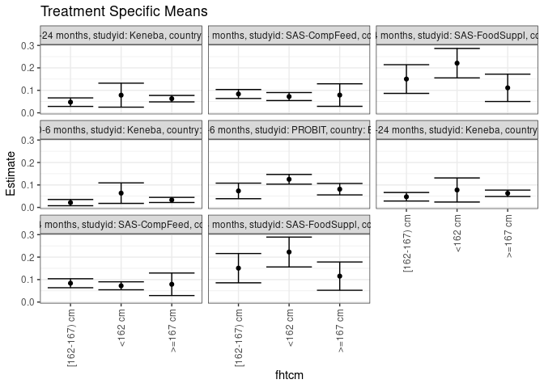

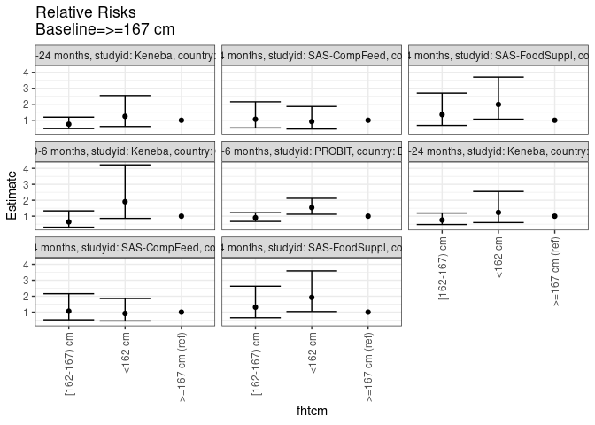

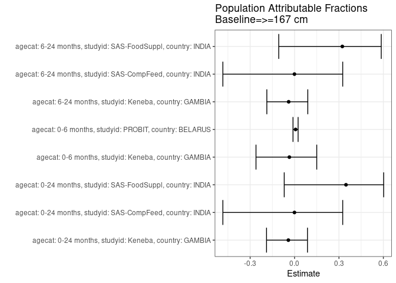

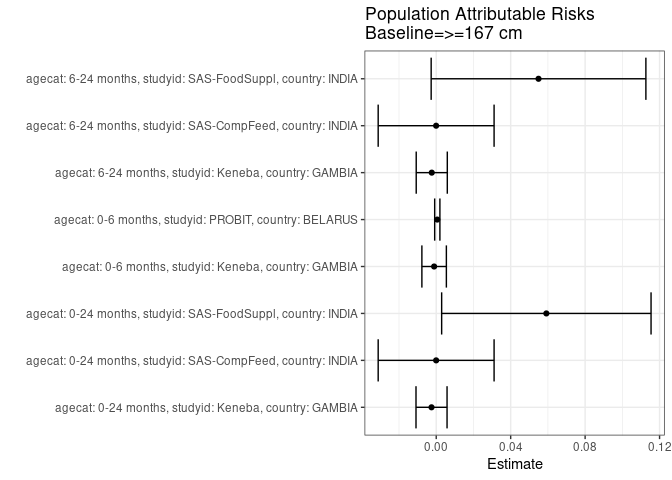

## Results Table

### Parameter: TSM

| agecat | studyid | country | intervention_level | baseline_level | estimate | ci_lower | ci_upper |
| --- | --- | --- | --- | --- | --- | --- | --- |
| 0-24 months | Keneba | GAMBIA | >=167 cm | NA | 0.0629953 | 0.0487183 | 0.0772724 |
| 0-24 months | Keneba | GAMBIA | <162 cm | NA | 0.0785385 | 0.0251953 | 0.1318818 |
| 0-24 months | Keneba | GAMBIA | [162-167) cm | NA | 0.0474715 | 0.0285228 | 0.0664201 |
| 0-24 months | SAS-CompFeed | INDIA | >=167 cm | NA | 0.0789386 | 0.0288172 | 0.1290600 |
| 0-24 months | SAS-CompFeed | INDIA | <162 cm | NA | 0.0722919 | 0.0545102 | 0.0900736 |
| 0-24 months | SAS-CompFeed | INDIA | [162-167) cm | NA | 0.0837014 | 0.0637281 | 0.1036746 |
| 0-24 months | SAS-FoodSuppl | INDIA | >=167 cm | NA | 0.1111014 | 0.0502963 | 0.1719066 |
| 0-24 months | SAS-FoodSuppl | INDIA | <162 cm | NA | 0.2208978 | 0.1553565 | 0.2864391 |
| 0-24 months | SAS-FoodSuppl | INDIA | [162-167) cm | NA | 0.1502906 | 0.0864207 | 0.2141606 |
| 0-6 months | Keneba | GAMBIA | >=167 cm | NA | 0.0333681 | 0.0219976 | 0.0447386 |
| 0-6 months | Keneba | GAMBIA | <162 cm | NA | 0.0636364 | 0.0180040 | 0.1092687 |
| 0-6 months | Keneba | GAMBIA | [162-167) cm | NA | 0.0214286 | 0.0075750 | 0.0352822 |
| 0-6 months | PROBIT | BELARUS | >=167 cm | NA | 0.0812257 | 0.0558369 | 0.1066146 |
| 0-6 months | PROBIT | BELARUS | <162 cm | NA | 0.1251797 | 0.1035788 | 0.1467806 |
| 0-6 months | PROBIT | BELARUS | [162-167) cm | NA | 0.0734501 | 0.0389036 | 0.1079966 |
| 6-24 months | Keneba | GAMBIA | >=167 cm | NA | 0.0628692 | 0.0485749 | 0.0771635 |
| 6-24 months | Keneba | GAMBIA | <162 cm | NA | 0.0776063 | 0.0240344 | 0.1311783 |
| 6-24 months | Keneba | GAMBIA | [162-167) cm | NA | 0.0474841 | 0.0285091 | 0.0664591 |
| 6-24 months | SAS-CompFeed | INDIA | >=167 cm | NA | 0.0789386 | 0.0288172 | 0.1290600 |
| 6-24 months | SAS-CompFeed | INDIA | <162 cm | NA | 0.0722919 | 0.0545102 | 0.0900736 |
| 6-24 months | SAS-CompFeed | INDIA | [162-167) cm | NA | 0.0837014 | 0.0637281 | 0.1036746 |
| 6-24 months | SAS-FoodSuppl | INDIA | >=167 cm | NA | 0.1153073 | 0.0523875 | 0.1782271 |
| 6-24 months | SAS-FoodSuppl | INDIA | <162 cm | NA | 0.2226144 | 0.1562175 | 0.2890113 |
| 6-24 months | SAS-FoodSuppl | INDIA | [162-167) cm | NA | 0.1507818 | 0.0855879 | 0.2159757 |

### Parameter: E(Y)

| agecat | studyid | country | intervention_level | baseline_level | estimate | ci_lower | ci_upper |
| --- | --- | --- | --- | --- | --- | --- | --- |
| 0-24 months | Keneba | GAMBIA | NA | NA | 0.0604651 | 0.0491978 | 0.0717324 |
| 0-24 months | SAS-CompFeed | INDIA | NA | NA | 0.0788835 | 0.0568416 | 0.1009254 |
| 0-24 months | SAS-FoodSuppl | INDIA | NA | NA | 0.1702703 | 0.1319196 | 0.2086209 |
| 0-6 months | Keneba | GAMBIA | NA | NA | 0.0322364 | 0.0232620 | 0.0412108 |
| 0-6 months | PROBIT | BELARUS | NA | NA | 0.0817924 | 0.0563990 | 0.1071859 |
| 6-24 months | Keneba | GAMBIA | NA | NA | 0.0604651 | 0.0491978 | 0.0717324 |
| 6-24 months | SAS-CompFeed | INDIA | NA | NA | 0.0788835 | 0.0568416 | 0.1009254 |
| 6-24 months | SAS-FoodSuppl | INDIA | NA | NA | 0.1702703 | 0.1319196 | 0.2086209 |

### Parameter: RR

| agecat | studyid | country | intervention_level | baseline_level | estimate | ci_lower | ci_upper |
| --- | --- | --- | --- | --- | --- | --- | --- |
| 0-24 months | Keneba | GAMBIA | >=167 cm | >=167 cm | 1.0000000 | 1.0000000 | 1.000000 |
| 0-24 months | Keneba | GAMBIA | <162 cm | >=167 cm | 1.2467361 | 0.6092981 | 2.551052 |
| 0-24 months | Keneba | GAMBIA | [162-167) cm | >=167 cm | 0.7535712 | 0.4759535 | 1.193120 |
| 0-24 months | SAS-CompFeed | INDIA | >=167 cm | >=167 cm | 1.0000000 | 1.0000000 | 1.000000 |
| 0-24 months | SAS-CompFeed | INDIA | <162 cm | >=167 cm | 0.9157992 | 0.4502393 | 1.862761 |
| 0-24 months | SAS-CompFeed | INDIA | [162-167) cm | >=167 cm | 1.0603357 | 0.5209083 | 2.158368 |
| 0-24 months | SAS-FoodSuppl | INDIA | >=167 cm | >=167 cm | 1.0000000 | 1.0000000 | 1.000000 |
| 0-24 months | SAS-FoodSuppl | INDIA | <162 cm | >=167 cm | 1.9882540 | 1.0680547 | 3.701265 |
| 0-24 months | SAS-FoodSuppl | INDIA | [162-167) cm | >=167 cm | 1.3527340 | 0.6773123 | 2.701692 |
| 0-6 months | Keneba | GAMBIA | >=167 cm | >=167 cm | 1.0000000 | 1.0000000 | 1.000000 |
| 0-6 months | Keneba | GAMBIA | <162 cm | >=167 cm | 1.9071023 | 0.8621358 | 4.218638 |
| 0-6 months | Keneba | GAMBIA | [162-167) cm | >=167 cm | 0.6421875 | 0.3092258 | 1.333669 |
| 0-6 months | PROBIT | BELARUS | >=167 cm | >=167 cm | 1.0000000 | 1.0000000 | 1.000000 |
| 0-6 months | PROBIT | BELARUS | <162 cm | >=167 cm | 1.5411332 | 1.1198429 | 2.120915 |
| 0-6 months | PROBIT | BELARUS | [162-167) cm | >=167 cm | 0.9042713 | 0.6695953 | 1.221195 |
| 6-24 months | Keneba | GAMBIA | >=167 cm | >=167 cm | 1.0000000 | 1.0000000 | 1.000000 |
| 6-24 months | Keneba | GAMBIA | <162 cm | >=167 cm | 1.2344097 | 0.5970535 | 2.552145 |
| 6-24 months | Keneba | GAMBIA | [162-167) cm | >=167 cm | 0.7552843 | 0.4766532 | 1.196791 |
| 6-24 months | SAS-CompFeed | INDIA | >=167 cm | >=167 cm | 1.0000000 | 1.0000000 | 1.000000 |
| 6-24 months | SAS-CompFeed | INDIA | <162 cm | >=167 cm | 0.9157992 | 0.4502393 | 1.862761 |
| 6-24 months | SAS-CompFeed | INDIA | [162-167) cm | >=167 cm | 1.0603357 | 0.5209083 | 2.158368 |
| 6-24 months | SAS-FoodSuppl | INDIA | >=167 cm | >=167 cm | 1.0000000 | 1.0000000 | 1.000000 |
| 6-24 months | SAS-FoodSuppl | INDIA | <162 cm | >=167 cm | 1.9306188 | 1.0385704 | 3.588865 |
| 6-24 months | SAS-FoodSuppl | INDIA | [162-167) cm | >=167 cm | 1.3076519 | 0.6519516 | 2.622823 |

### Parameter: PAR

| agecat | studyid | country | intervention_level | baseline_level | estimate | ci_lower | ci_upper |
| --- | --- | --- | --- | --- | --- | --- | --- |
| 0-24 months | Keneba | GAMBIA | >=167 cm | NA | -0.0025302 | -0.0108722 | 0.0058119 |
| 0-24 months | SAS-CompFeed | INDIA | >=167 cm | NA | -0.0000551 | -0.0311953 | 0.0310852 |
| 0-24 months | SAS-FoodSuppl | INDIA | >=167 cm | NA | 0.0591689 | 0.0029112 | 0.1154266 |
| 0-6 months | Keneba | GAMBIA | >=167 cm | NA | -0.0011317 | -0.0077112 | 0.0054478 |
| 0-6 months | PROBIT | BELARUS | >=167 cm | NA | 0.0005667 | -0.0008350 | 0.0019684 |
| 6-24 months | Keneba | GAMBIA | >=167 cm | NA | -0.0024041 | -0.0107544 | 0.0059462 |
| 6-24 months | SAS-CompFeed | INDIA | >=167 cm | NA | -0.0000551 | -0.0311953 | 0.0310852 |
| 6-24 months | SAS-FoodSuppl | INDIA | >=167 cm | NA | 0.0549630 | -0.0027240 | 0.1126500 |

### Parameter: PAF

| agecat | studyid | country | intervention_level | baseline_level | estimate | ci_lower | ci_upper |
| --- | --- | --- | --- | --- | --- | --- | --- |
| 0-24 months | Keneba | GAMBIA | >=167 cm | NA | -0.0418456 | -0.1892683 | 0.0873025 |
| 0-24 months | SAS-CompFeed | INDIA | >=167 cm | NA | -0.0006982 | -0.4844362 | 0.3254026 |
| 0-24 months | SAS-FoodSuppl | INDIA | >=167 cm | NA | 0.3474997 | -0.0697208 | 0.6019927 |
| 0-6 months | Keneba | GAMBIA | >=167 cm | NA | -0.0351060 | -0.2604545 | 0.1499539 |
| 0-6 months | PROBIT | BELARUS | >=167 cm | NA | 0.0069284 | -0.0104270 | 0.0239857 |
| 6-24 months | Keneba | GAMBIA | >=167 cm | NA | -0.0397598 | -0.1873356 | 0.0894735 |
| 6-24 months | SAS-CompFeed | INDIA | >=167 cm | NA | -0.0006982 | -0.4844362 | 0.3254026 |
| 6-24 months | SAS-FoodSuppl | INDIA | >=167 cm | NA | 0.3227985 | -0.1069064 | 0.5856905 |